# Homework: Reading in Data

Oliver Titus

## Instructions

Big picture: Read in the Medicare and Medicaid General Payments Data and conduct an exploratory data analysis. You should use both SAS and R to explore the data, but you might choose to use R for certain tasks and SAS for other tasks.

When you are finished with the assignment:

1. Save the file as 04_Lastname_Firstname.Rmd and compile it
2. Commit the Rmd file and corresponding html file to your homework git repo
3. Push the commit to github
4. Locate the Rmd file on github and click on the SHA link for the file
5. Paste the url of the resulting page into Canvas to submit your assignment.

Your assignment must compile on a different computer as long as the saspath is set correctly for that machine. This means you will need to use a local file path when you read the data in via R (and SAS). So when you specify your file path, it should look something like “General_Payment_Data_Sample.csv” with no “/home/xxx/Documents” or “C:\” in front of it.

### About the Data

To get this data, I started with the full 2018 dataset, and limited it to cash payments made to medical doctors reported in January. The full dataset is *way* too big - several GB when stored on disk.

A sample of the full dataset is available in the template repository (and also [here](https://github.com/srvanderplas/unl-stat850/raw/master/data/General_Payment_Data_Sample.csv)). It’s 8MB after extreme trimming of the less useful columns and sampling 25% of the rows. You can read about the data [here](https://openpaymentsdata.cms.gov/about) and [here](https://www.cms.gov/openpayments/).

### Questions to Address

- Describe the dataset and any interesting things you find within.
- What tasks are easier in R? SAS?
- What do you find that might need to be cleaned up or corrected before analysis?

You may want to include graphics (using the sample code in the book, or the [R Graph Gallery](https://www.r-graph-gallery.com/)) to show any interesting things you discover. When you include a graph, be sure to provide some contextual description of the information you want someone to take away from the graph.

## Data Exploration

### R

(You don’t need to keep these headings, but I want you to have a skeleton of what the code chunks should look like)

## Summary Statistics

```r
library(readr)
library(knitr)
library(skimr)
data <- read_csv("https://github.com/srvanderplas/unl-stat850/raw/master/data/General_Payment_Data_Sample.csv")
head(data, 10) %>% kable()
```

| Change_Type | Physician_Profile_ID | Recipient_Primary_Business_Street_Address_Line1 | Recipient_City | Recipient_State | Recipient_Zip_Code | Recipient_Country | Recipient_Province | Recipient_Postal_Code | Physician_Specialty | Submitting_Applicable_Manufacturer_or_Applicable_GPO_Name | Applicable_Manufacturer_or_Applicable_GPO_Making_Payment_ID | Applicable_Manufacturer_or_Applicable_GPO_Making_Payment_Name | Applicable_Manufacturer_or_Applicable_GPO_Making_Payment_State | Applicable_Manufacturer_or_Applicable_GPO_Making_Payment_Country | Total_Amount_of_Payment_USDollars | Date_of_Payment | Number_of_Payments_Included_in_Total_Amount | Nature_of_Payment_or_Transfer_of_Value | City_of_Travel | State_of_Travel | Country_of_Travel | Physician_Ownership_Indicator | Third_Party_Payment_Recipient_Indicator | Name_of_Third_Party_Entity_Receiving_Payment_or_Transfer_of_Value | Charity_Indicator | Third_Party_Equals_Covered_Recipient_Indicator | Contextual_Information | Record_ID | Covered_or_Noncovered_Indicator_1 | … |
| --- | --- | --- | --- | --- | --- | --- | --- | --- | --- | --- | --- | --- | --- | --- | --- | --- | --- | --- | --- | --- | --- | --- | --- | --- | --- | --- | --- | --- | --- | --- |
| UNCHANGED | 219097 | 1840 MEASE DR | SAFETY HARBOR | FL | 34695-6602 | United States | . | . | Allopathic & Osteopathic Physicians\|Internal Medicine\|Interventional Cardiology | PORTOLA PHARMACEUTICALS, INC. | 1e+11 | PORTOLA PHARMACEUTICALS, INC. | CA | United States | 22.6 | 01/11/2018 | 1 | Food and Beverage | . | . | . | No | No Third Party Payment | . | . | . | . | 6.11e+08 | Covered | … |
| UNCHANGED | 176033 | 200 E Chestnut St | Louisville | KY | 40202 | United States | . | . | Allopathic & Osteopathic Physicians\|Hospitalist | Bristol-Myers Squibb Company | 1e+11 | E.R. Squibb & Sons, L.L.C. | NJ | United States | 13.2 | 01/03/2018 | 1 | Food and Beverage | . | . | . | No | No Third Party Payment | . | No | . | . | 5.72e+08 | Covered | … |
| UNCHANGED | 359089 | 450 CLARKSON AVE | BROOKLYN | NY | 11203-2056 | United States | . | . | Allopathic & Osteopathic Physicians\|Pathology\|Blood Banking & Transfusion Medicine | Shire North American Group Inc | 1e+11 | Shire North American Group Inc | MA | United States | 156.2 | 01/19/2018 | 1 | Compensation for services other than consulting, including serving as faculty or as a speaker at a venue other than a continuing education program | . | . | . | No | No Third Party Payment | . | . | . | . | 5.66e+08 | Covered | … |
| UNCHANGED | 492208 | 1510 S CENTRAL AVE | GLENDALE | CA | 91204 | United States | . | . | Allopathic & Osteopathic Physicians\|Pediatrics | Cranial Technologies, Inc | 1e+11 | Cranial Technologies, Inc | AZ | United States | 15.6 | 01/17/2018 | 1 | Food and Beverage | . | . | . | No | No Third Party Payment | . | . | . | . | 6.06e+08 | Covered | … |
| UNCHANGED | 249590 | 6780 INDIANA AVE | RIVERSIDE | CA | 92506-4270 | United States | . | . | Allopathic & Osteopathic Physicians\|Family Medicine | Eisai Inc. | 1e+11 | Eisai Inc. | NJ | United States | 16.4 | 01/18/2018 | 1 | Food and Beverage | . | . | . | No | No Third Party Payment | . | No | . | . | 6.04e+08 | Covered | … |
| UNCHANGED | 1249679 | 818 W King St | Owosso | MI | 48867-2116 | United States | . | . | Allopathic & Osteopathic Physicians\|Psychiatry & Neurology\|Neurology | Biogen, Inc. | 1e+11 | Biogen, Inc. | MA | United States | 66.7 | 01/05/2018 | 1 | Travel and Lodging | New Orleans | LA | United States | No | No Third Party Payment | . | No | . | . | 5.54e+08 | Covered | … |
| UNCHANGED | 84093 | 16040 Park Valley Dr | Round Rock | TX | 78681-3578 | United States | . | . | Allopathic & Osteopathic Physicians\|Psychiatry & Neurology\|Neurology | Biogen, Inc. | 1e+11 | Biogen, Inc. | MA | United States | 22.6 | 01/13/2018 | 1 | Food and Beverage | . | . | . | No | No Third Party Payment | . | No | . | . | 5.64e+08 | Covered | … |
| UNCHANGED | 228873 | 8243 MEADOWBRIDGE RD | MECHANICSVILLE | VA | 23116 | United States | . | . | Allopathic & Osteopathic Physicians\|Internal Medicine\|Cardiovascular Disease | Abbott Laboratories | 1e+11 | Abbott Laboratories | IL | United States | 5000.0 | 01/18/2018 | 1 | Consulting Fee | . | . | . | No | No Third Party Payment | . | . | . | . | 6.13e+08 | Covered | … |
| UNCHANGED | 160575 | 3289 Woodburn Rd Ste 350 | Annandale | VA | 22003 | United States | . | . | Allopathic & Osteopathic Physicians\|Internal Medicine\|Pulmonary Disease | Boehringer Ingelheim Pharmaceuticals, Inc. | 1e+11 | Boehringer Ingelheim Pharmaceuticals, Inc. | CT | United States | 3565.0 | 01/05/2018 | 1 | Compensation for services other than consulting, including serving as faculty or as a speaker at a venue other than a continuing education program | . | . | . | No | No Third Party Payment | . | No | . | . | 5.78e+08 | Non-Covered | … |
| UNCHANGED | 157039 | 101 MAIN ST | MEDFORD | MA | 02155-4540 | United States | . | . | Allopathic & Osteopathic Physicians\|Internal Medicine\|Pulmonary Disease | Sunovion Pharmaceuticals Inc. | 1e+11 | Sunovion Pharmaceuticals Inc. | MA | United States | 850.0 | 01/11/2018 | 1 | Compensation for services other than consulting, including serving as faculty or as a speaker at a venue other than a continuing education program | . | . | . | No | No Third Party Payment | . | No | . | . | 6.08e+08 | Covered | … |

```r
skim(data)
```

Data summary

| Name | data |
| --- | --- |
| Number of rows | 22302 |
| Number of columns | 34 |
| _______________________ |  |
| Column type frequency: |  |
| character | 29 |
| numeric | 5 |
| ________________________ |  |
| Group variables | None |

**Variable type: character**

| skim_variable | n_missing | complete_rate | min | max | empty | n_unique | whitespace |
| --- | --- | --- | --- | --- | --- | --- | --- |
| Change_Type | 0 | 1 | 3 | 9 | 0 | 3 | 0 |
| Recipient_Primary_Business_Street_Address_Line1 | 0 | 1 | 5 | 55 | 0 | 13781 | 0 |
| Recipient_City | 0 | 1 | 2 | 27 | 0 | 3418 | 0 |
| Recipient_State | 0 | 1 | 1 | 2 | 0 | 56 | 0 |
| Recipient_Zip_Code | 0 | 1 | 1 | 10 | 0 | 9274 | 0 |
| Recipient_Country | 0 | 1 | 6 | 18 | 0 | 3 | 0 |
| Recipient_Province | 0 | 1 | 1 | 16 | 0 | 3 | 0 |
| Recipient_Postal_Code | 0 | 1 | 1 | 7 | 0 | 3 | 0 |
| Physician_Specialty | 0 | 1 | 1 | 115 | 0 | 192 | 0 |
| Submitting_Applicable_Manufacturer_or_Applicable_GPO_Name | 0 | 1 | 6 | 77 | 0 | 562 | 0 |
| Applicable_Manufacturer_or_Applicable_GPO_Making_Payment_Name | 0 | 1 | 6 | 77 | 0 | 614 | 0 |
| Applicable_Manufacturer_or_Applicable_GPO_Making_Payment_State | 0 | 1 | 1 | 2 | 0 | 38 | 0 |
| Applicable_Manufacturer_or_Applicable_GPO_Making_Payment_Country | 0 | 1 | 5 | 18 | 0 | 15 | 0 |
| Date_of_Payment | 0 | 1 | 10 | 10 | 0 | 31 | 0 |
| Nature_of_Payment_or_Transfer_of_Value | 0 | 1 | 4 | 146 | 0 | 14 | 0 |
| City_of_Travel | 0 | 1 | 1 | 20 | 0 | 723 | 0 |
| State_of_Travel | 0 | 1 | 1 | 2 | 0 | 52 | 0 |
| Country_of_Travel | 0 | 1 | 1 | 20 | 0 | 34 | 0 |
| Physician_Ownership_Indicator | 0 | 1 | 2 | 3 | 0 | 2 | 0 |
| Third_Party_Payment_Recipient_Indicator | 0 | 1 | 6 | 22 | 0 | 3 | 0 |
| Name_of_Third_Party_Entity_Receiving_Payment_or_Transfer_of_Value | 0 | 1 | 1 | 50 | 0 | 746 | 0 |
| Charity_Indicator | 0 | 1 | 1 | 3 | 0 | 3 | 0 |
| Third_Party_Equals_Covered_Recipient_Indicator | 0 | 1 | 1 | 3 | 0 | 3 | 0 |
| Contextual_Information | 0 | 1 | 1 | 500 | 0 | 456 | 0 |
| Covered_or_Noncovered_Indicator_1 | 0 | 1 | 1 | 11 | 0 | 3 | 0 |
| Indicate_Drug_or_Biological_or_Device_or_Medical_Supply_1 | 0 | 1 | 1 | 14 | 0 | 5 | 0 |
| Product_Category_or_Therapeutic_Area_1 | 0 | 1 | 1 | 77 | 0 | 600 | 0 |
| Name_of_Drug_or_Biological_or_Device_or_Medical_Supply_1 | 0 | 1 | 1 | 95 | 0 | 1453 | 0 |
| Associated_Drug_or_Biological_NDC_1 | 0 | 1 | 1 | 12 | 0 | 386 | 0 |

**Variable type: numeric**

| skim_variable | n_missing | complete_rate | mean | sd | p0 | p25 | p50 | p75 | p100 | hist |
| --- | --- | --- | --- | --- | --- | --- | --- | --- | --- | --- |
| Physician_Profile_ID | 0 | 1 | 4.12e+05 | 5.58e+05 | 2.40e+01 | 1.24e+05 | 2.45e+05 | 3.67e+05 | 5.71e+06 | ▇▁▁▁▁ |
| Applicable_Manufacturer_or_Applicable_GPO_Making_Payment_ID | 0 | 1 | 1.00e+11 | 4.79e+04 | 1.00e+11 | 1.00e+11 | 1.00e+11 | 1.00e+11 | 1.00e+11 | ▇▁▁▁▁ |
| Total_Amount_of_Payment_USDollars | 0 | 1 | 9.61e+02 | 7.41e+03 | 1.10e-01 | 1.32e+01 | 2.27e+01 | 3.34e+02 | 5.07e+05 | ▇▁▁▁▁ |
| Number_of_Payments_Included_in_Total_Amount | 0 | 1 | 1.03e+00 | 5.50e-01 | 1.00e+00 | 1.00e+00 | 1.00e+00 | 1.00e+00 | 3.00e+01 | ▇▁▁▁▁ |
| Record_ID | 0 | 1 | 5.85e+08 | 2.58e+07 | 5.21e+08 | 5.68e+08 | 5.91e+08 | 6.08e+08 | 6.18e+08 | ▂▂▅▃▇ |

## Plots

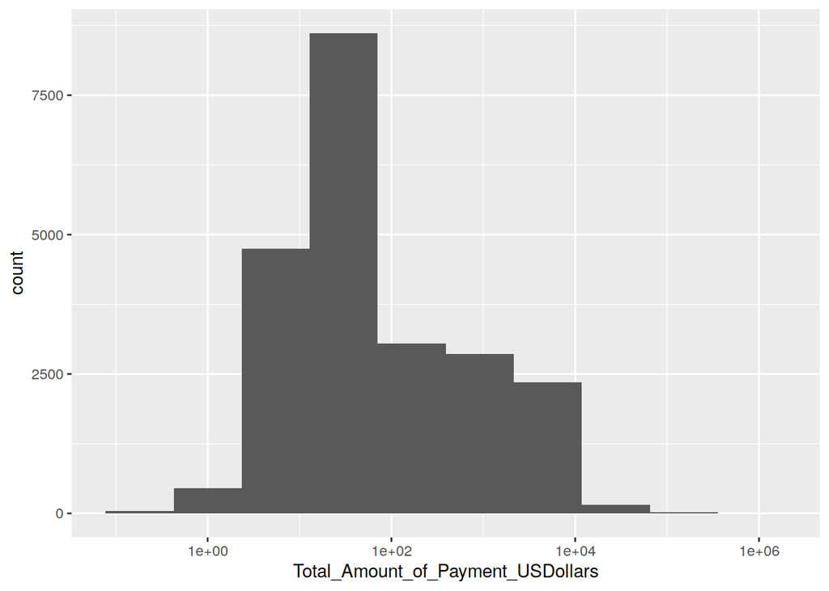

```r
library(ggplot2)
ggplot(data, aes(x=Total_Amount_of_Payment_USDollars)) + geom_histogram(bins = 10) + scale_x_log10()
```

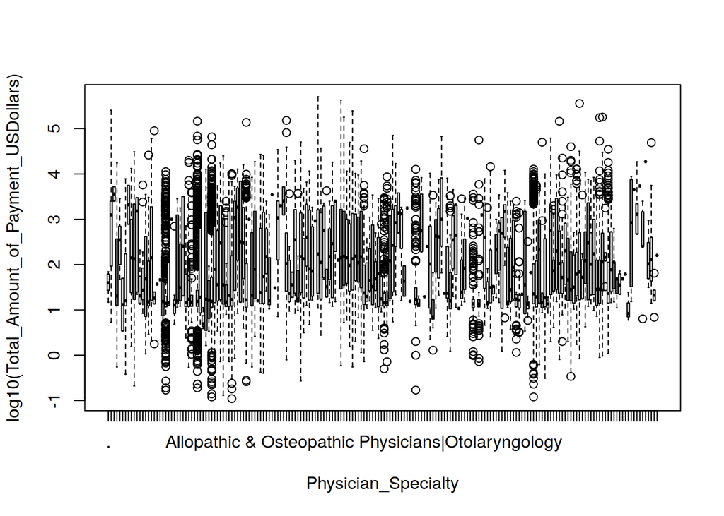

```r
boxplot(log10(Total_Amount_of_Payment_USDollars) ~ Physician_Specialty, data = data)
```

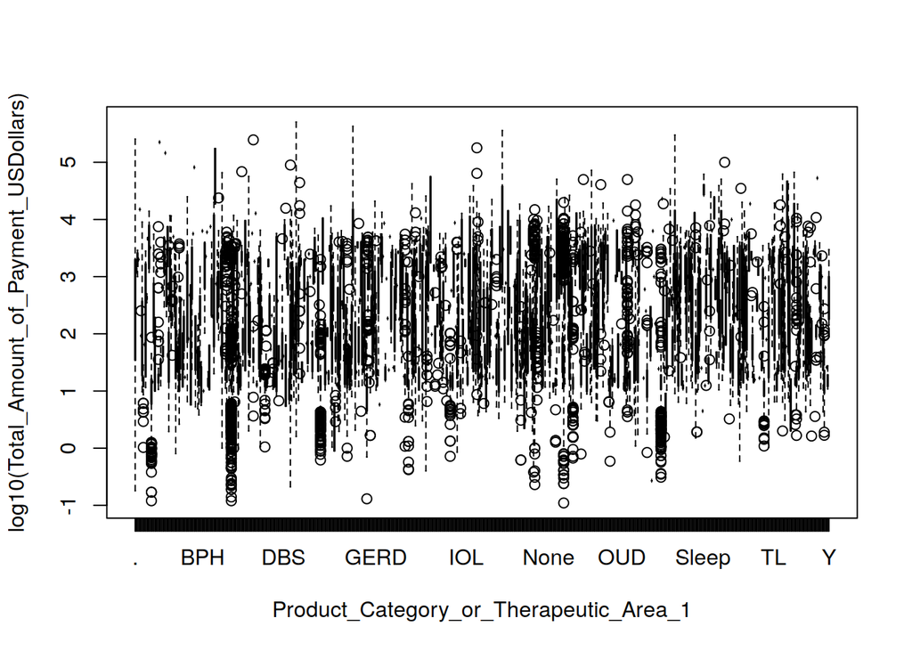

```r
boxplot(log10(Total_Amount_of_Payment_USDollars) ~ Product_Category_or_Therapeutic_Area_1, data = data)
```

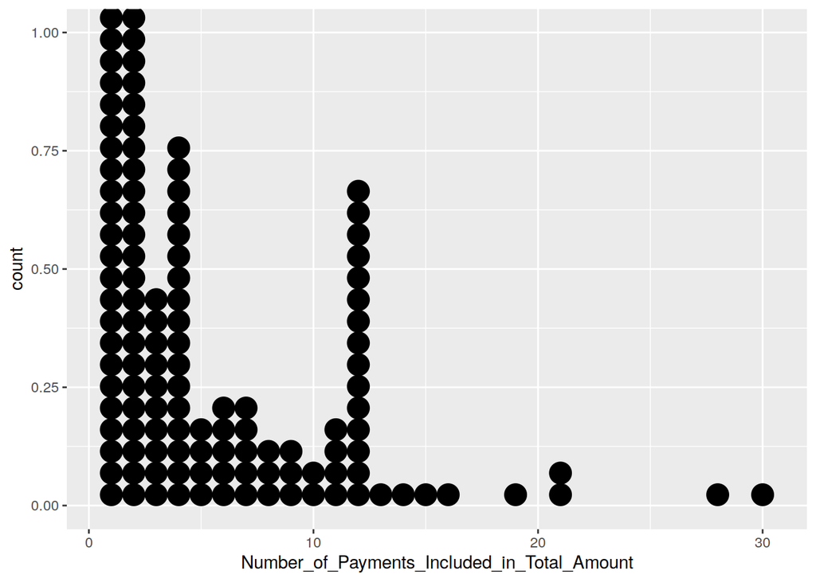

```r
ggplot(data, aes(x=Number_of_Payments_Included_in_Total_Amount)) + geom_dotplot()
```

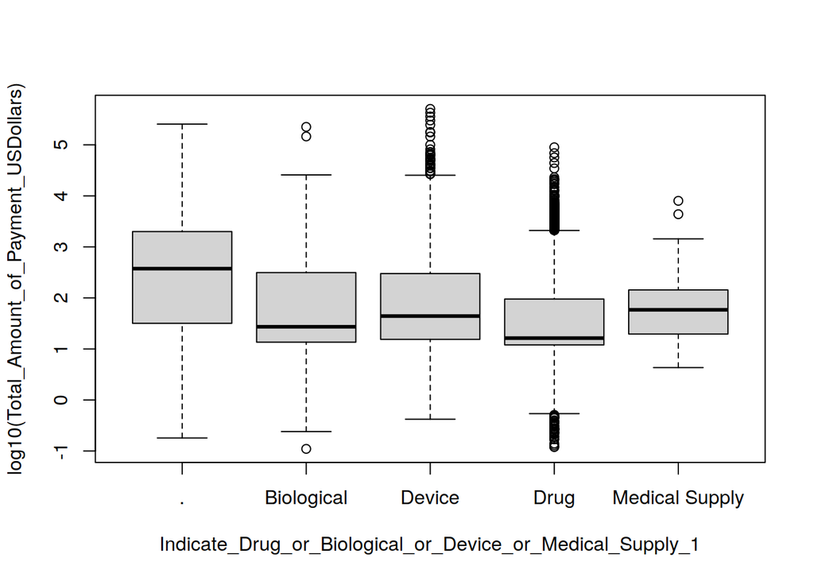

```r
boxplot(log10(Total_Amount_of_Payment_USDollars) ~ Indicate_Drug_or_Biological_or_Device_or_Medical_Supply_1, data = data)
```

The box plot categorizes the total amount of payment with physician specialty. We can see that there are many specialties. Some of them have a different spread of the payments than others, so it is likely that the mean payment is different for each specialty. We’ll do an ANOVA to confirm this suspicion. I tried using ggplot for this, but I don’t think it was able to handle the amount of categories. If we we wanted to have a nicer, more readable box plots, the amount of categories would have to be reduced. Looking in the dataset, many of the categories seem to focus on a specific disease they specialize in like for example, an internal medicine doctor who does cardiovascular disease. It may be better to compare the amount of payments to doctors based on if they are in internal medicine vs. family medicine vs. dermatology, etc. This would reduce the amount of categories.

A box plot for total of payment and product category was also created. This plot has the same issue that there are a lot of categories, but it still gives us a sense as to if there are differences in mean payment based on the product category. An F test is also done to see if this may be the case.

The dot plot shows the distribution for the number of payments. We see that most of them are one payment.

Another box plot was made for whether the product was a drug, biological, device, or medical supply. Looking at the box plots, there are some differences in variation in the total payment between these categories.

Let’s look at the ANOVA results for comparing the total amount of payments with physician specialty along with another ANOVA comparing total payment with product category:

## ANOVA

```r
summary(aov(data$Total_Amount_of_Payment_USDollars ~ data$Physician_Specialty))
```

```
##                             Df   Sum Sq  Mean Sq F value Pr(>F)
## data$Physician_Specialty   191 4.35e+10 2.28e+08    4.26 <2e-16 ***
## Residuals                22110 1.18e+12 5.34e+07
## ---
## Signif. codes:  0 '***' 0.001 '**' 0.01 '*' 0.05 '.' 0.1 ' ' 1
```

```r
summary(aov(data$Total_Amount_of_Payment_USDollars ~ data$Product_Category_or_Therapeutic_Area_1))
```

```
##                                                Df   Sum Sq  Mean Sq F value
## data$Product_Category_or_Therapeutic_Area_1   599 2.24e+11 3.73e+08    8.09
## Residuals                                   21702 1.00e+12 4.61e+07
##                                             Pr(>F)
## data$Product_Category_or_Therapeutic_Area_1 <2e-16 ***
## Residuals
## ---
## Signif. codes:  0 '***' 0.001 '**' 0.01 '*' 0.05 '.' 0.1 ' ' 1
```

```r
summary(aov(data$Total_Amount_of_Payment_USDollars ~ data$Indicate_Drug_or_Biological_or_Device_or_Medical_Supply_1))
```

```
##                                                                   Df   Sum Sq
## data$Indicate_Drug_or_Biological_or_Device_or_Medical_Supply_1     4 6.22e+09
## Residuals                                                      22297 1.22e+12
##                                                                 Mean Sq F value
## data$Indicate_Drug_or_Biological_or_Device_or_Medical_Supply_1 1.55e+09    28.4
## Residuals                                                      5.47e+07
##                                                                Pr(>F)
## data$Indicate_Drug_or_Biological_or_Device_or_Medical_Supply_1 <2e-16 ***
## Residuals
## ---
## Signif. codes:  0 '***' 0.001 '**' 0.01 '*' 0.05 '.' 0.1 ' ' 1
```

The first ANOVA returns an overall F-test with an F-value of 4.26 and p-value close to 0.000, meaning there is highly statistically significant evidence that the amount of payments made between each physician is different for at least one specialty.If we were to analyze this data further, based on the large degrees of freedom for the physician specialty, it’d be better to reduce the number of categories so that if we wanted to compare each mean payment for one physician type to another, it would not be so many t-tests and that would also produce results that are easier to summarize.

The ANOVA for product category returns an overall F-test that is highly significant with an F-value of 8.09 and corresponding p-value very close to 0.000. This means that there is high statistical evidence that at least one mean payment for each product category is different. We would run into the same problem analyzing this further in that the degrees of freedom is 599, which is a lot of product categories to compare. If we were to clean up this data, making product categories that are broader may help with this analysis.

The last ANOVA for if the product is a drug, biological, device, or medical supply also returns an overall F-test that is highly significant with an F-value of 28.4. This has a corresponding p-value very close to 0, so there is highly statistically significant evidence that at least one of the mean total payments are different based on these classifications.

### SAS

Fill in your code in the chunk below.

## Contents of the data:

```
filename dat "General_Payment_Data_Sample.csv";

PROC IMPORT DATAFILE = dat OUT = openmedpay
    DBMS = CSV
    REPLACE;
    GETNAMES = YES;
    GUESSINGROWS = 3500;
RUN;

DATA openmedpay;
set openmedpay;
RUN;

PROC CONTENTS VARNUM DATA= openmedpay ;

RUN;
```

| Data Set Name | WORK.OPENMEDPAY | Observations | 22302 |
| --- | --- | --- | --- |
| Member Type | DATA | Variables | 34 |
| Engine | V9 | Indexes | 0 |
| Created | 09/18/2020 13:15:39 | Observation Length | 1168 |
| Last Modified | 09/18/2020 13:15:39 | Deleted Observations | 0 |
| Protection |  | Compressed | NO |
| Data Set Type |  | Sorted | NO |
| Label |  |  |  |
| Data Representation | SOLARIS_X86_64, LINUX_X86_64, ALPHA_TRU64, LINUX_IA64 |  |  |
| Encoding | latin1 Western (ISO) |  |  |

| Engine/Host Dependent Information |  |
| --- | --- |
| Data Set Page Size | 98304 |
| Number of Data Set Pages | 266 |
| First Data Page | 1 |
| Max Obs per Page | 84 |
| Obs in First Data Page | 78 |
| Number of Data Set Repairs | 0 |
| Filename | /tmp/SAS_work6EBF000077A0_yeti/openmedpay.sas7bdat |
| Release Created | 9.0401M6 |
| Host Created | Linux |
| Inode Number | 41686534 |
| Access Permission | rw-rw-r– |
| Owner Name | susan |
| File Size | 25MB |
| File Size (bytes) | 26247168 |

| Variables in Creation Order # | Variables in Creation Order Variable | Variables in Creation Order Type | Variables in Creation Order Len | Variables in Creation Order Format | Variables in Creation Order Informat |
| --- | --- | --- | --- | --- | --- |
| 1 | Change_Type | Char | 9 | $9. | $9. |
| 2 | Physician_Profile_ID | Num | 8 | BEST12. | BEST32. |
| 3 | Recipient_Primary_Business_Stree | Char | 55 | $55. | $55. |
| 4 | Recipient_City | Char | 19 | $19. | $19. |
| 5 | Recipient_State | Char | 2 | $2. | $2. |
| 6 | Recipient_Zip_Code | Char | 10 | $10. | $10. |
| 7 | Recipient_Country | Char | 18 | $18. | $18. |
| 8 | Recipient_Province | Char | 16 | $16. | $16. |
| 9 | Recipient_Postal_Code | Char | 7 | $7. | $7. |
| 10 | Physician_Specialty | Char | 115 | $115. | $115. |
| 11 | Submitting_Applicable_Manufactur | Char | 45 | $45. | $45. |
| 12 | Applicable_Manufacturer_or_Appli | Num | 8 | BEST12. | BEST32. |
| 13 | VAR13 | Char | 61 | $61. | $61. |
| 14 | VAR14 | Char | 2 | $2. | $2. |
| 15 | VAR15 | Char | 18 | $18. | $18. |
| 16 | Total_Amount_of_Payment_USDollar | Num | 8 | BEST12. | BEST32. |
| 17 | Date_of_Payment | Num | 8 | MMDDYY10. | MMDDYY10. |
| 18 | Number_of_Payments_Included_in_T | Num | 8 | BEST12. | BEST32. |
| 19 | Nature_of_Payment_or_Transfer_of | Char | 148 | $148. | $148. |
| 20 | City_of_Travel | Char | 19 | $19. | $19. |
| 21 | State_of_Travel | Char | 2 | $2. | $2. |
| 22 | Country_of_Travel | Char | 20 | $20. | $20. |
| 23 | Physician_Ownership_Indicator | Char | 3 | $3. | $3. |
| 24 | Third_Party_Payment_Recipient_In | Char | 22 | $22. | $22. |
| 25 | Name_of_Third_Party_Entity_Recei | Char | 50 | $50. | $50. |
| 26 | Charity_Indicator | Char | 3 | $3. | $3. |
| 27 | Third_Party_Equals_Covered_Recip | Char | 3 | $3. | $3. |
| 28 | Contextual_Information | Char | 257 | $257. | $257. |
| 29 | Record_ID | Num | 8 | BEST12. | BEST32. |
| 30 | Covered_or_Noncovered_Indicator_ | Char | 11 | $11. | $11. |
| 31 | Indicate_Drug_or_Biological_or_D | Char | 14 | $14. | $14. |
| 32 | Product_Category_or_Therapeutic_ | Char | 77 | $77. | $77. |
| 33 | Name_of_Drug_or_Biological_or_De | Char | 95 | $95. | $95. |
| 34 | Associated_Drug_or_Biological_ND | Char | 12 | $12. | $12. |

PROC contents gives us some more details about the data set. It shows that data type each variable is as well as the format.

## Summary Statistics

```
proc MEANS data=openmedpay;
run;

proc MEANS data=openmedpay;
class Indicate_Drug_or_Biological_or_D;
run;
```

Variable

N

Mean

Std Dev

Minimum

Maximum

| Physician_Profile_ID |
| --- |
| Applicable_Manufacturer_or_Appli |
| Total_Amount_of_Payment_USDollar |
| Date_of_Payment |
| Number_of_Payments_Included_in_T |
| Record_ID |

| 22302 |
| --- |
| 22302 |
| 22302 |
| 22302 |
| 22302 |
| 22302 |

| 411507.81 |
| --- |
| 100000020416 |
| 961.4580396 |
| 21201.38 |
| 1.0274415 |
| 584696435 |

| 558203.56 |
| --- |
| 47939.86 |
| 7411.83 |
| 8.7860574 |
| 0.5490679 |
| 25782783.69 |

| 24.0000000 |
| --- |
| 100000000053 |
| 0.1100000 |
| 21185.00 |
| 1.0000000 |
| 520978703 |

| 5705345.00 |
| --- |
| 100000321808 |
| 507211.27 |
| 21215.00 |
| 30.0000000 |
| 617846857 |

| Indicate_Drug_or_Biological_or_D | N Obs | Variable | N | Mean | Std Dev | Minimum | Maximum |
| --- | --- | --- | --- | --- | --- | --- | --- |
| Biological | 2618 | Physician_Profile_ID Applicable_Manufacturer_or_Appli Total_Amount_of_Payment_USDollar Date_of_Payment Number_of_Payments_Included_in_T Record_ID | 2618 2618 2618 2618 2618 2618 | 370741.41 100000011393 806.4623147 21199.73 1.0171887 573303971 | 451178.06 32396.88 5492.69 9.0648458 0.5858563 23550236.49 | 136.0000000 100000000053 0.1100000 21185.00 1.0000000 521121401 | 5692311.00 100000181748 225000.00 21215.00 28.0000000 617834007 |
| Device | 7335 | Physician_Profile_ID Applicable_Manufacturer_or_Appli Total_Amount_of_Payment_USDollar Date_of_Payment Number_of_Payments_Included_in_T Record_ID | 7335 7335 7335 7335 7335 7335 | 478681.52 100000015917 1235.37 21201.72 1.0449898 585199952 | 668402.15 37852.93 11124.62 8.6939079 0.6717196 28314970.98 | 49.0000000 100000000057 0.4200000 21185.00 1.0000000 520978703 | 5705345.00 100000321808 507211.27 21215.00 30.0000000 617846857 |
| Drug | 9979 | Physician_Profile_ID Applicable_Manufacturer_or_Appli Total_Amount_of_Payment_USDollar Date_of_Payment Number_of_Payments_Included_in_T Record_ID | 9979 9979 9979 9979 9979 9979 | 351648.90 100000024775 513.3161399 21201.53 1.0027057 586642860 | 454187.70 56152.78 1878.62 8.7290572 0.1339110 23413370.71 | 24.0000000 100000000053 0.1200000 21185.00 1.0000000 527786995 | 5704900.00 100000291821 89662.50 21215.00 10.0000000 617787919 |
| Medical Supply | 41 | Physician_Profile_ID Applicable_Manufacturer_or_Appli Total_Amount_of_Payment_USDollar Date_of_Payment Number_of_Payments_Included_in_T Record_ID | 41 41 41 41 41 41 | 361277.32 100000025423 431.5875610 21201.95 1.0000000 577950942 | 313173.81 38207.66 1410.54 9.4470927 0 28142194.24 | 33699.00 100000000257 4.3100000 21185.00 1.0000000 521122715 | 1163786.00 100000116376 8000.00 21214.00 1.0000000 616786171 |

The means procedure gives us the summary statistics for numeric values in the dataset. I also made a proc means based on the classification variable “Indicate_Drug_or_Biological_or_Device_or_Medical_Supply_1” since it had the least amount of categories.

## Plots

```
PROC FREQ DATA=openmedpay ORDER=FORMATTED;
  TABLES Number_of_Payments_Included_in_T/ PLOTS=freqplot(type=dotplot);
RUN;

proc sgplot data=openmedpay;
title "Box plot: Payments for each physician type";
  vbox Total_Amount_of_Payment_USDollar / group=Physician_Specialty;
run;

proc sgplot data=openmedpay;
title "Box plot: Payments for each product category";
  vbox Total_Amount_of_Payment_USDollar / group=Product_Category_or_Therapeutic_;
run;

proc sgplot data=openmedpay;
title "Box plot: Payments for drug, biological, or device";
  vbox Total_Amount_of_Payment_USDollar / group=Indicate_Drug_or_Biological_or_D;
run;

PROC sgplot  DATA = openmedpay;
title "Scatter plot: Number of payments vs Total Payment";
   scatter y=Total_Amount_of_Payment_USDollar x = Number_of_Payments_Included_in_T;
RUN;
```

| Number_of_Payments_Included_in_T | Frequency | Percent | Cumulative Frequency | Cumulative Percent |
| --- | --- | --- | --- | --- |
| 1 | 22191 | 99.50 | 22191 | 99.50 |
| 2 | 34 | 0.15 | 22225 | 99.65 |
| 3 | 10 | 0.04 | 22235 | 99.70 |
| 4 | 17 | 0.08 | 22252 | 99.78 |
| 5 | 4 | 0.02 | 22256 | 99.79 |
| 6 | 5 | 0.02 | 22261 | 99.82 |
| 7 | 5 | 0.02 | 22266 | 99.84 |
| 8 | 3 | 0.01 | 22269 | 99.85 |
| 9 | 3 | 0.01 | 22272 | 99.87 |
| 10 | 2 | 0.01 | 22274 | 99.87 |
| 11 | 4 | 0.02 | 22278 | 99.89 |
| 12 | 15 | 0.07 | 22293 | 99.96 |
| 13 | 1 | 0.00 | 22294 | 99.96 |
| 14 | 1 | 0.00 | 22295 | 99.97 |
| 15 | 1 | 0.00 | 22296 | 99.97 |
| 16 | 1 | 0.00 | 22297 | 99.98 |
| 19 | 1 | 0.00 | 22298 | 99.98 |
| 21 | 2 | 0.01 | 22300 | 99.99 |
| 28 | 1 | 0.00 | 22301 | 100.00 |
| 30 | 1 | 0.00 | 22302 | 100.00 |

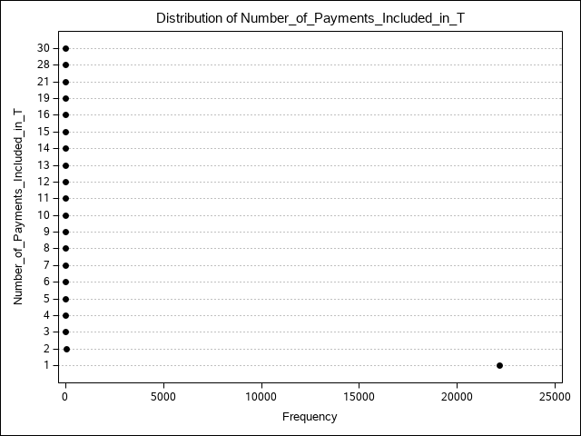

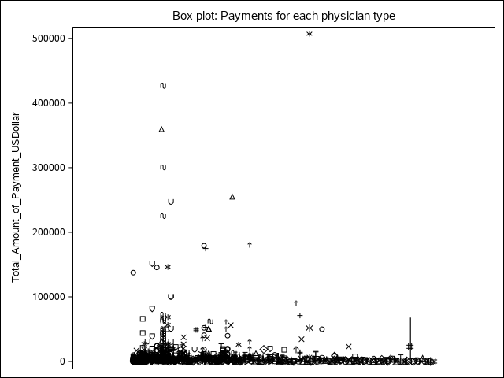

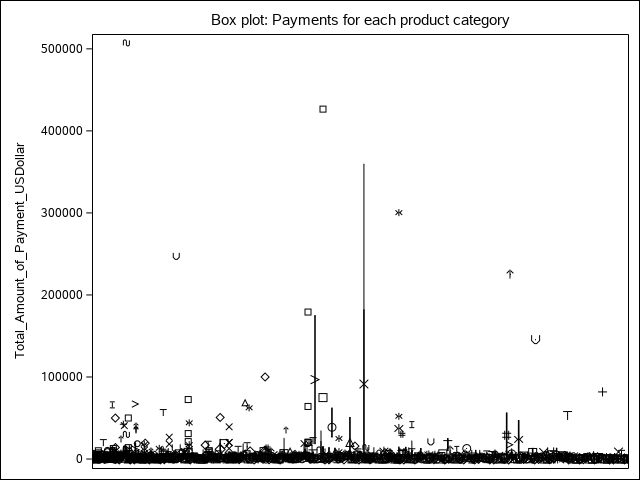

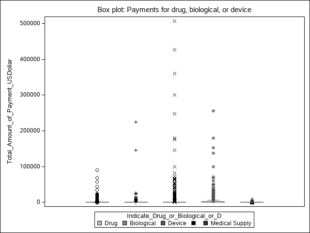

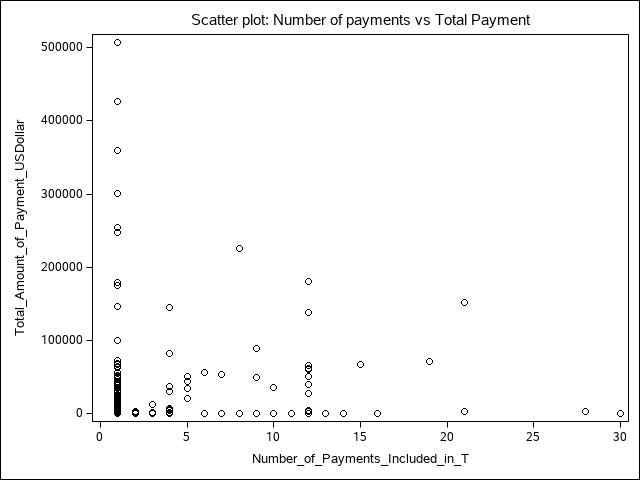

## ANOVA

[output not shown]

| ANOVA: Total Payment vs. If it's a drug, biological, or device |
| --- |

| Class Level Information Class | Class Level Information Levels | Class Level Information Values |
| --- | --- | --- |
| Indicate_Drug_or_Biological_or_D | 4 | Biological Device Drug Medical Supply |

| Number of Observations Read | 22302 |
| --- | --- |
| Number of Observations Used | 19973 |

| ANOVA: Total Payment vs. If it's a drug, biological, or device |
| --- |

Dependent Variable: Total_Amount_of_Payment_USDollar

| Source | DF | Sum of Squares | Mean Square | F Value | Pr > F |
| --- | --- | --- | --- | --- | --- |
| Model | 3 | 2210565559.7 | 736855186.56 | 14.40 | <.0001 |
| Error | 19969 | 1.0218839E12 | 51173512.833 |  |  |
| Corrected Total | 19972 | 1.0240944E12 |  |  |  |

| R-Square | Coeff Var | Root MSE | Total_Amount_of_Payment_USDollar Mean |
| --- | --- | --- | --- |
| 0.002159 | 875.8628 | 7153.566 | 816.7451 |

| Source | DF | Anova SS | Mean Square | F Value | Pr > F |
| --- | --- | --- | --- | --- | --- |
| Indicate_Drug_or_Bio | 3 | 2210565560 | 736855187 | 14.40 | <.0001 |

| ANOVA: Total Payment vs. Physician Specialty |
| --- |

| Class Level Information Class | Class Level Information Levels | Class Level Information Values |
| --- | --- | --- |
| Physician_Specialty | 191 | Allopathic & Osteopathic Physicians\|Allergy & Immunology Allopathic & Osteopathic Physicians\|Allergy & Immunology\|Allergy Allopathic & Osteopathic Physicians\|Anesthesiology Allopathic & Osteopathi… |

| Number of Observations Read | 22302 |
| --- | --- |
| Number of Observations Used | 22295 |

| ANOVA: Total Payment vs. Physician Specialty |
| --- |

Dependent Variable: Total_Amount_of_Payment_USDollar

| Source | DF | Sum of Squares | Mean Square | F Value | Pr > F |
| --- | --- | --- | --- | --- | --- |
| Model | 190 | 43451508284 | 228692148.86 | 4.28 | <.0001 |
| Error | 22104 | 1.1816532E12 | 53458793.787 |  |  |
| Corrected Total | 22294 | 1.2251047E12 |  |  |  |

| R-Square | Coeff Var | Root MSE | Total_Amount_of_Payment_USDollar Mean |
| --- | --- | --- | --- |
| 0.035468 | 760.2370 | 7311.552 | 961.7464 |

| Source | DF | Anova SS | Mean Square | F Value | Pr > F |
| --- | --- | --- | --- | --- | --- |
| Physician_Specialty | 190 | 43451508284 | 228692149 | 4.28 | <.0001 |

| ANOVA: Total Payment vs. Product Category |
| --- |

| Class Level Information Class | Class Level Information Levels | Class Level Information Values |
| --- | --- | --- |
| Product_Category_or_Therapeutic_ | 599 | 1 ACNE ACTIMMUNE ACUTE CARE ADHD AED ANASTOCLIP ANTI-INFECTIVE ARTHROPLASTY ARTHROSCOPY AT - Fixed interventional x-ray/angiography fluoroscopy ATHERECTOMY ATRIAL FIBRILATION ATRIAL FIBRILLATION AUTOI… |

| Number of Observations Read | 22302 |
| --- | --- |
| Number of Observations Used | 19898 |

| ANOVA: Total Payment vs. Product Category |
| --- |

Dependent Variable: Total_Amount_of_Payment_USDollar

| Source | DF | Sum of Squares | Mean Square | F Value | Pr > F |
| --- | --- | --- | --- | --- | --- |
| Model | 598 | 218947713798 | 366133300.67 | 9.03 | <.0001 |
| Error | 19299 | 782935854668 | 40568726.601 |  |  |
| Corrected Total | 19897 | 1.0018836E12 |  |  |  |

| R-Square | Coeff Var | Root MSE | Total_Amount_of_Payment_USDollar Mean |
| --- | --- | --- | --- |
| 0.218536 | 793.7094 | 6369.358 | 802.4799 |

| Source | DF | Anova SS | Mean Square | F Value | Pr > F |
| --- | --- | --- | --- | --- | --- |
| Product_Category_or_ | 598 | 218947713798 | 366133300.67 | 9.03 | <.0001 |

Looking at these ANOVAs, they yield the same conclusions that were made in the R code, however, the F-Values are not the same, but they sill correspond to p-values less than 0.05. I wonder if R and SAS have different ways of calculating the F-value at least for the ANOVA procedure.

> Yes. R uses a different sum of squares calculation than SAS. https://rcompanion.org/rcompanion/d_04.html

In terms of comparing R and SAS, I think R is much easier for certain tasks in that there seems to be less coding, but SAS does seem to have its advantages as well. The plots look better in SAS in my opinion and the output in SAS for the ANOVAs has more detail than R in that it list all the categories associated with that ANOVA.

> Once you learn how to customize plots in R (and clean up the data a bit) I think your opinion might change :) But I agree, right now, SAS defaults are a bit better. Part of that is that SAS limits the length of variable names by default, where R will let you use any variable names.

If we wanted to do a more concise analysis, the amount of product categories and physician specialties would need to be reduced since those variable seem to be important for the total payments. We see in the output for the ANOVAs in SAS that there are 191 physician specialties and 599 product categories which is a lot and would make comparing those means a very tedious task.